# Datos bivariados

Felipe González

### Matrices de gráficas de dispersión

Una manera de analizar más de dos variables numéricas es mediante *matrices de gráficas de dispersión*, esta técnica nos permite considerar las relaciones entre cada par de variables.

En el siguiente ejemplo consideramos los datos de *Iris* de Fisher (la información fue recolectada por el botanista Edgar Anderson en los años treinta). El objetivo detrás de la recolección de los datos era cuantificar la variación geográfica de un tipo de flores. La base de datos contiene 4 mediciones: ancho y largo de pétalos y sépalos, para 50 especímenes de tres especies distintas de flores (iris setosa, iris virginica e iris versicolor).

```r
library(GGally) # aquí esta la función para hacer la matriz
head(iris)
```

```
  Sepal.Length Sepal.Width Petal.Length Petal.Width Species
1          5.1         3.5          1.4         0.2  setosa
2          4.9         3.0          1.4         0.2  setosa
3          4.7         3.2          1.3         0.2  setosa
4          4.6         3.1          1.5         0.2  setosa
5          5.0         3.6          1.4         0.2  setosa
6          5.4         3.9          1.7         0.4  setosa
```

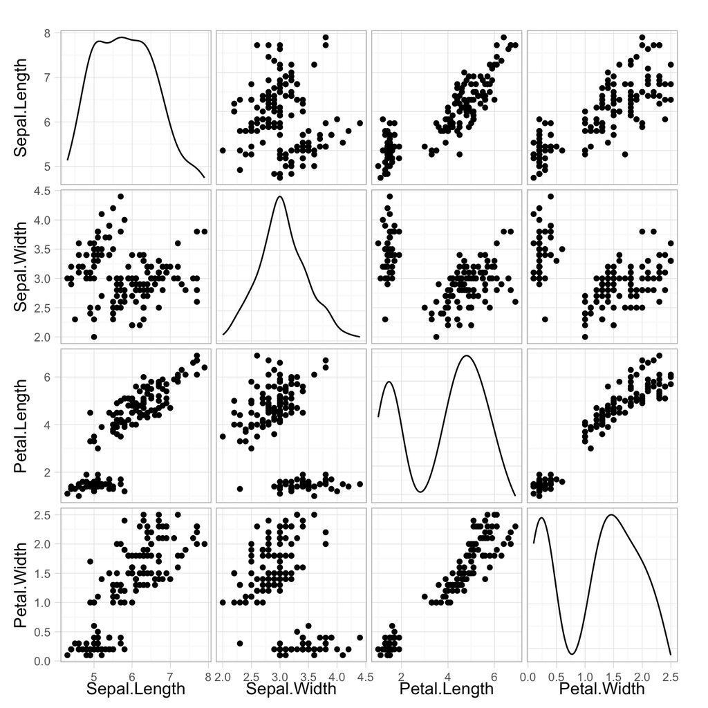

```r
ggpairs(data = iris, # data.frame with variables
  columns=1:4, # columns to plot, default to all,
  upper = list(continuous = 'points'))
```

Este tipo de gráfica da una mirada rápida que muestra posibles asociaciones interesantes entre todas las variables que consideramos.

### Covarianza y correlación

Covarianza y correlación son mediadas de asociación lineal entre dos mediciones. Si las mediciones $x$ y $y$ son $(x_1,y_1),(x_2,y_2),...,(x_n,y_n)$ entonces la *covarianza* entre estas dos mediciones es:

$s_{x,y}^2=\frac{1}{n-1}\sum_{i=1}^n(x_i-\mu_x)(y_i-\mu_y)$

donde $\mu_x$ y $\mu_y$ son las medias de las mediciones correspondientes. La *correlación* es:

$\rho_{x,y}=\frac{s_{x,y}^2}{s_x s_y}$

donde $s_x$ y $s_y$ son las desviaciones estándar dadas por:

$s_x = \sqrt{\frac{1}{n-1}\sum_{i=1}^n(x_i-\mu_x)^2}$

Nótese que la correlación es la covarianza de las *variables estandarizadas*, y que ambas medidas son simétricas respecto a $x$ y $y$. Se puede demostrar que $-1\le\rho_{x,y}\le 1$ (usando la desigualdad de Cauchy-Schwarz).

En general es más fácil interpretar la correlación, pues no depende de las unidades de medición. En primer lugar, la relación entre mediciones con correlación cercana a 1 o -1 puede describirse bien mediante una recta (los datos siguen el patrón de una recta y los residuales son chicos). Valores cercanos a 1 inidican que las mediciones tienden a moverse en la misma dirección (linealmente) a lo largo de los casos, y valores cercanos a -1 señalan que las mediciones se mueven en dirección opuesta (cuando una sube, la otra baja), también linealmente. Valores cercanos a cero indican que no hay una relación lineal clara.

```r
set.seed(40827834)
# correlación cercana a uno
x_1 <- rnorm(300)
y_1 <- x_1 + 0.2 * rnorm(300)
cor(x_1, y_1)
```

```
[1] 0.982
```

```r
plot_1 <- qplot(x_1, y_1) + geom_smooth(method = "lm")

# correlación positiva alrededor de 0.7
x_2 <- rnorm(300)
y_2 <- x_2 + rnorm(300)
cor(x_2, y_2)
```

```
[1] 0.745
```

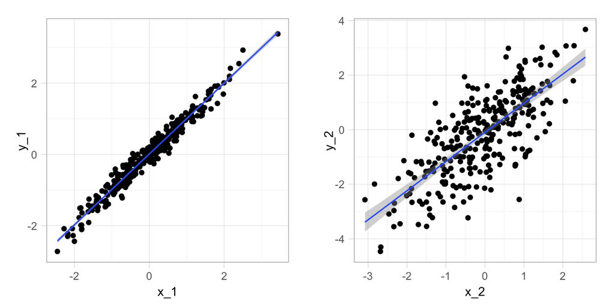

```r
plot_2 <- qplot(x_2, y_2) + geom_smooth(method = "lm")

grid.arrange(plot_1, plot_2, ncol = 2)
```

```r
# correlación cercana a 0.3
x_1 <- rnorm(300)
y_1 <- x_1 + 3 * rnorm(300)
cor(x_1, y_1)
```

```
[1] 0.325
```

```r
plot_1 <- qplot(x_1, y_1) + geom_smooth(method = "lm")

# correlación positiva alrededor de -0.7
x_2 <- rnorm(300)
y_2 <- - x_2 + rnorm(300)
cor(x_2, y_2)
```

```
[1] -0.663
```

```r
plot_2 <- qplot(x_2, y_2) + geom_smooth(method = "lm")

# correlación cercana a cero
x_3 <- rnorm(300)
y_3 <- 0* x_3 + rnorm(300)
cor(x_3, y_3)
```

```
[1] 0.0407
```

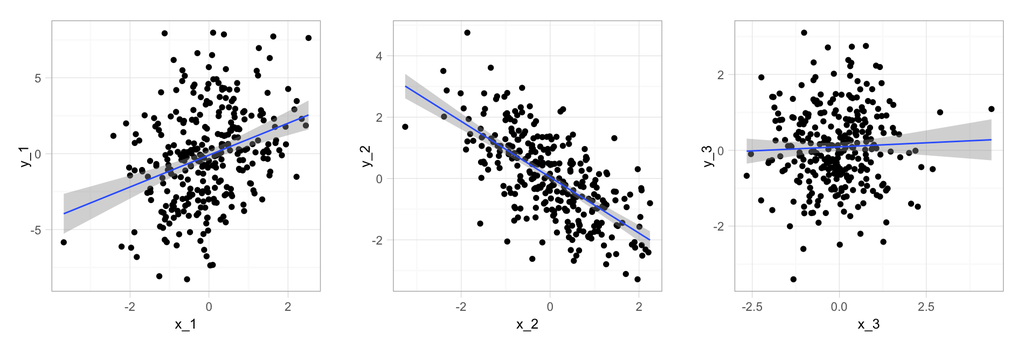

```r
plot_3 <- qplot(x_3, y_3) + geom_smooth(method = "lm")

grid.arrange(plot_1, plot_2, plot_3, ncol = 3)
```

Vemos que la pendiente de las rectas ajustadas depende tanto de la correlación como de la dispersión entre $x$ y $y$. No obstante, la correlación es invariante a transformaciones lineales de las variables.

Es importante tener cuidado en la interpretación. En el siguiente ejemplo, la correlación es cercana a cero, sin embargo una variable determina a la otra.

```r
x <- rnorm(300)
y <- x ^ 2
cor(x, y)
```

```
[1] 0.101
```

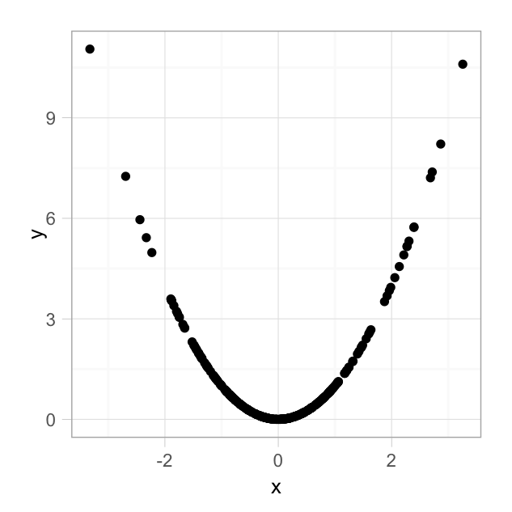

```r
qplot(x, y)
```

Correlaciones para los iris: para el ejemplo de los iris, podemos calcular $4*3/2$ correlaciones distintas. Ponemos estos datos en una matriz:

| $\rho$ | Sepal.Length | Sepal.Width | Petal.Length | Petal.Width |
| --- | --- | --- | --- | --- |
| Sepal.Length | 1.00 | -0.12 | **0.87** | **0.82** |
| Sepal.Width | -0.12 | 1.00 | **-0.43** | **-0.37** |
| Petal.Length | **0.87** | **-0.43** | 1.00 | **0.96** |
| Petal.Width | **0.82** | **-0.37** | **0.96** | 1.00 |

Esta matriz se llama *matriz de correlaciones*.

¿Cuándo usar correlación y covarianza en el análisis exploratorio? Como estas medidas no son resistentes, y por el hecho de que su interpretación es difícil, generalmente preferimos no usarlas cuando exploramos; sin embargo, cuando la asociación entre dos variables es claramente lineal pueden ser resúmenes efectivos.

## Asociación entre variables categóricas.

La *tabla de contingencias* es la manera usual de presentar mediciones categóricas conjuntas. Abajo presentamos una tabla con las variables color de ojos y de pelo, las observaciones corresponden a 592 estudiantes de estadística. En cada celda ponemos el número de observaciones en el conjunto de datos que corresponden a las categorías de renglón y de columna.

| . | Castaño | Azúl | Miel | Verde | Total |
| --- | --- | --- | --- | --- | --- |
| Negro | 68 | 20 | 15 | 5 | 108 |
| Castaño | 119 | 84 | 54 | 29 | 286 |
| Rojo | 26 | 17 | 14 | 14 | 71 |
| Rubio | 7 | 94 | 10 | 16 | 127 |
| **Total** | 220 | 215 | 93 | 64 | 592 |

Buscamos entender si hay asociación lineal entre las dos variables categóricas. El problema con la tabla de arriba es que no se pueden hacer comparaciones de las columnas y los renglones de manera fácil.

Calculamos las distribuciones condicionales de color de pelo dada cada categoría de color de ojos (dividiendo cada celda por el total de observaciones en la columna correspondiente):

| . | Castaño | Azúl | Miel | Verde | Total |
| --- | --- | --- | --- | --- | --- |
| Negro | 0.31 | 0.09 | 0.16 | 0.08 | 0.18 |
| Castaño | 0.54 | 0.39 | 0.58 | 0.45 | 0.48 |
| Rojo | 0.12 | 0.08 | 0.15 | 0.22 | 0.12 |
| Rubio | 0.03 | 0.44 | 0.11 | 0.25 | 0.21 |
| **Total** | 220 | 215 | 93 | 64 | 592 |

Hemos dejado la última fila con el número de casos por columna (más adelante explicaremos por qué). En esta última tabla es fácil comparar cualquier par de columnas. El primer tipo de comparación es el de la distribución condicional del color de pelo dada una categoría versus la distribución total de color de pelo (última columna). También podemos comparar columnas que corresponden a distintas categorías de color de ojos.

Cuando no existe asociación fuerte entre las dos variables categóricas, esperaríamos que cada una de las columnas fuera parecida a la columna de total. Claramente no es el caso con esta tabla, donde vemos que el color de ojos azúl esta asociado con pelo rubio y el color de ojos castaño con pelo negro, por ejemplo.

Dividiendo cada proporción de cada categoría de ojos x pelo entre la proporción total para el color de pelo correspondiente obtenemos momios (o índices si se multiplican por 100) que a veces son más fáciles de leer:

[output not shown]

Esta tabla se interpreta de la siguiente forma: en nuestra muestra, alguien que tiene los ojos azules tiene el doble de probabilidad de tener el pelo rubio que alguien de la muestra total. También podemos calcular que la probabilidad de que alguien que tiene los ojos azúles tiene pelo rubio es 2.04/0.15 = 13 veces la probabilidad de que alguien que tiene ojos castaños tenga pelo rubio.

En resumen, vemos una asociación clara entre ojos castaños y pelo negro y castaño, entre ojos azules y pelo rubio, y también entre ojos verdes y cabello rojo. Podemos marcar con colores las diferencias notables entre entre las distribuciones condicionales de cada color de ojos y la distribución total de color de ojos (por ejemplo marcando índices por arriba de 1.20 y por abajo de 0.80).

**Observaciones:**

1. Recordemos que por ahora solo estamos describiendo los datos. Que la asociación que encontramos en esta tabla realemente exista en la población total se requiere de otras consideraciones de la inferencia estadística (por ejemplo, tenemos que saber, por ejemplo, cómo se recolectaron los datos y en particular, cómo se seleccionó a las personas de la muestra). A pesar de estar describiendo la muestra debemos ser cuidadosos, vale la pena observar que cuando tenemos columnas con muy pocas observaciones debemos ser cautelosos con las conclusiones que obtenemos de nuestro análisis: por ejemplo, si la columna de color de ojos verdes tuviera 10 observaciones no convendría guiarse mucho por la forma de la distribución condicional de esa columna.
2. El análisis se puede hacer también comparando las condicionales dados los distintos colores de pelo. Cuando pensamps que una variable es la respuesta y la otra es el factor entonces conviene condicionar en los valores del factor. En el ejemplo de arriba, estamos considerando el color de ojos como el factor y el color de pelo como la respuesta (aunque en este ejemplo no hay razón para hacerlo así).
3. Podemos entender la tabla de momios en términos de evaluación de ajuste y residuales de un modelo. Sea $n_{ij}$ la cantidad de observaciones en la celda $i,j$, $n_i=\sum_j n_{ij}, n^j=\sum_i n_{ij}$ y $n=\sum_{i,j} n_{ij}$. Calculamos las distribuciones condicionales dada la variable de las columnas como $n_{ij}/n^j$. La distribución marginal de la variable en los renglones es $n_i/n$. Entonces la tabla de cocientes esta dada por: $r_{ij}=\frac{n_{ij}/n^j}{n_i/n}$ y analizamos las desviaciones de estas cantidades alrededor de 1. Cuando todas estas cantidades son cercanas a 1, las marginales son iguales a la marginal (que interpretamos como independencia). Tomando logaritmo de la ecuación anterior, y reacomodadndo llegamos a, $\log(n_{ij})=\log(\bigg(\frac{n_i n_j}{n}\bigg)) + \epsilon_{ij},$ que también se puede escribir como $\log(n_{ij})=-\log(n) + \log(n_i) + \log(n_j) + \epsilon_{ij},$ que aclara la naturaleza del modelo: el observado es igual a un egecto general mas un efecto de los renglones, más un efecto de las columnas y mas un residual.  
   Los residuales $\epsilon_{ij}$ nos indican desviaciones de la celdas a partir del modelo de independencia: residuales positivos grandes quiere decir que en la celda correspondiente hay más casos de los que uno esperaría si las variables fueran independientes. Aunque podemos usar estos residuales para hacer análisis es más común usar los cocientes (que son el exponencial de los residuales).

Podemos analizar la relación entre más variables categóricas usando tablas de dimensión más alta.

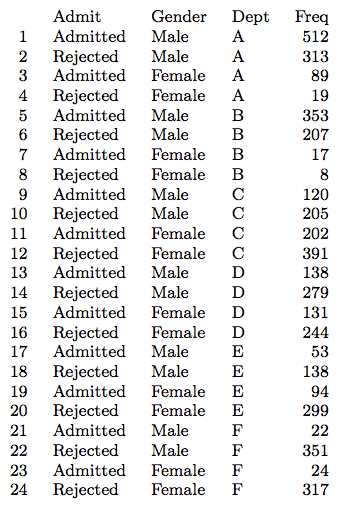

Las tablas de frecuencias totales y proporciones por columna podrían sugerir que los hombres que solicitan tienen mayor probabilidad de entrar a la univesidad:

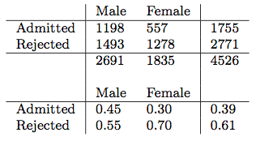

donde vemos que es 0.45/0.30=1.47 veces más probable que un hombre del conjunto de los solicitantes haya sido aceptado que una mujer.

Sin embargo, las tasas de aceptación por departamento son muy distintas:

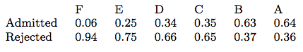

Podemos hacer dos tablas separadas por hombres y mujeres para comparar las tasas de aceptación de cada departamento_

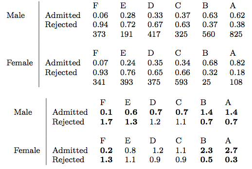

y aquí no vemos ningún sesgo claro hacia la acpetación de hombre, en todo caso, el departamento A parecería tener un sesgo en favor de las mujeres.

**Paradoja de Simpson.** El ejemplo anterior ilustra la paradoja de Simpson: la relación entre dos variables tienen una forma dentro de cada grupo, pero cuando agrupamos esta forma se invierte. Esto es difícil de pensar si pensamos en términos de caudalidad pero no tan misterioso si pensamos (más correctamente) en términos de asociación.

En nuestro ejemplo, probabilidad de aceptación y sexo están asociados: un hombre tiene mayor probabilidad de ser aceptado que una mujer. Sin embargo, no hay una relación de causalidad directa entre estas dos variables: una razón de tasas bajas para las mujeres es, por ejemplo, que no están solicitando entrar en los departamentos a los que es fácil entrar (A y B).

Otro ejemplo relacionado con esta paradoja se puede ver cuando examinamos la correlación entre longitud de pétalo y ancho de sépalo en el ejemplo de iris. En este caso obtuvimos una correlación negativa, pero la situación cambia si examinamos cada especie por separado.

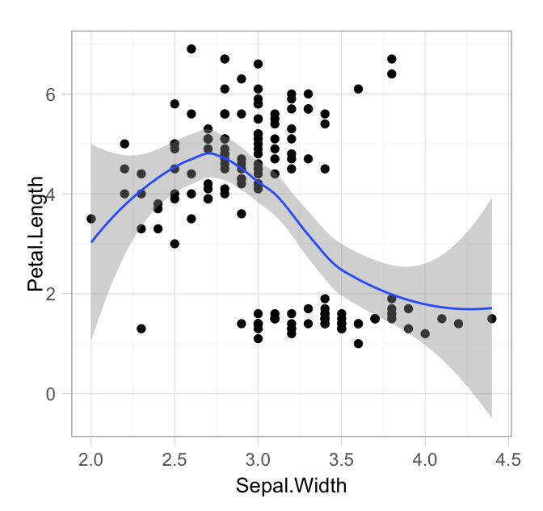

```r
# a total
ggplot(iris, aes(x = Sepal.Width, y = Petal.Length)) +
  geom_point() +
  geom_smooth()
```

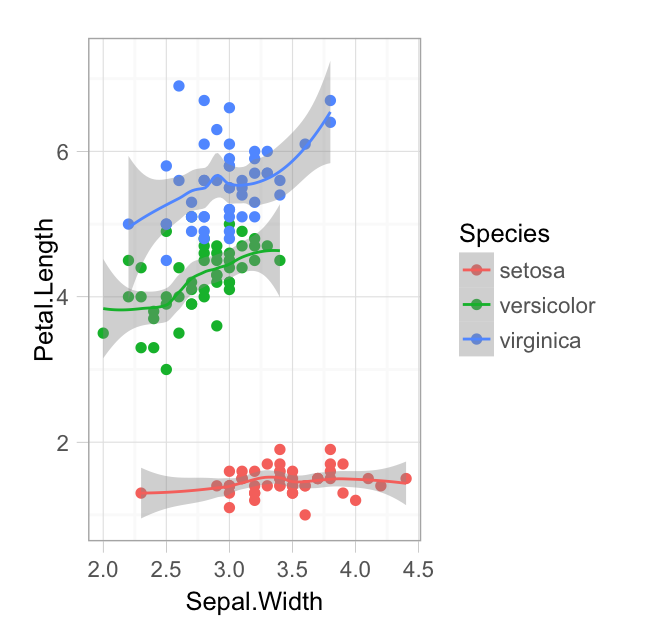

```r
# separando por grupo
ggplot(iris, aes(x = Sepal.Width, y = Petal.Length, color = Species)) +
  geom_point() +
  geom_smooth()
```

Podemos examinar mejor cada especie si estandarizamos cada una de las variables dentro de cada grupo, donde confirmammos que la relación es positiva y similar dentro de cada especie, una vez que escalamos a los tamaños de cada una.

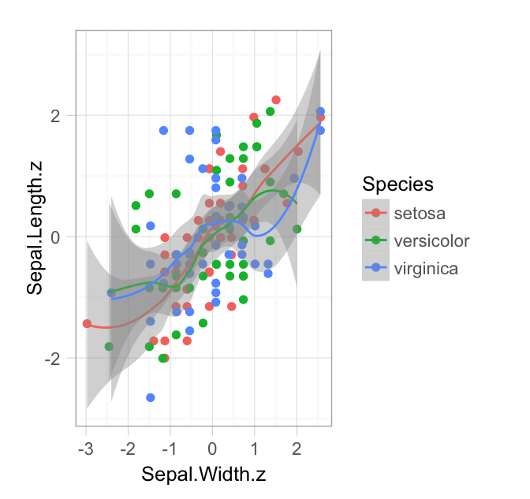

```r
iris_scale <- iris %>%
  group_by(Species) %>%
  mutate(
    Sepal.Width.z = scale(Sepal.Width)[, 1],
    Sepal.Length.z = scale(Sepal.Length)[, 1]
    )

ggplot(iris_scale, aes(x = Sepal.Width.z, y = Sepal.Length.z, color = Species)) +
  geom_point() +
  geom_smooth()
```